# Lab 05 - Permutational ANOVA

Nonparametric statistics ay 2021/2022

2022/10/14

*Disclaimer: The present material has been slightly adapted from the original R script prepared by me for the a.y. 2020/2021 Nonparametric statistics course. I hereby assume responsibility for any error that may be present in this document, I do apologise for them and invite you to let me know.*

```r
B = 1000
seed = 26111992
```

## Permutational ANOVA

Until now, we have seen how to perform basic statistical tests in a nonparametric and, mainly and more importantly, in a permutational framework. By going further on this line of thinking, one can perform analysis of variance in a fully permutational (and thus exact…) setting. The example we will see today is about a fairly old dataset, appeared on Biometrika in 1948 (!!). It is about an experiment over a number of chickens, fed with different feed types, which were weighted by the experimenter. You are interested in determining if the feed type has an impact on the chicken weight or not.

Let’s import and summarise the dataset

```r
chickwts
```

| weight | feed |
| --- | --- |
| 179 | horsebean |
| 160 | horsebean |
| 136 | horsebean |
| 227 | horsebean |
| 217 | horsebean |
| 168 | horsebean |
| 108 | horsebean |
| 124 | horsebean |
| 143 | horsebean |
| 140 | horsebean |

[output cut: 61 more lines]

```r
attach(chickwts)
summary(chickwts)
```

```
##      weight             feed
##  Min.   :108.0   casein   :12
##  1st Qu.:204.5   horsebean:10
##  Median :258.0   linseed  :12
##  Mean   :261.3   meatmeal :11
##  3rd Qu.:323.5   soybean  :14
##  Max.   :423.0   sunflower:12
```

and, let’s try to plot the results, to get a bit of info about what’s going on…

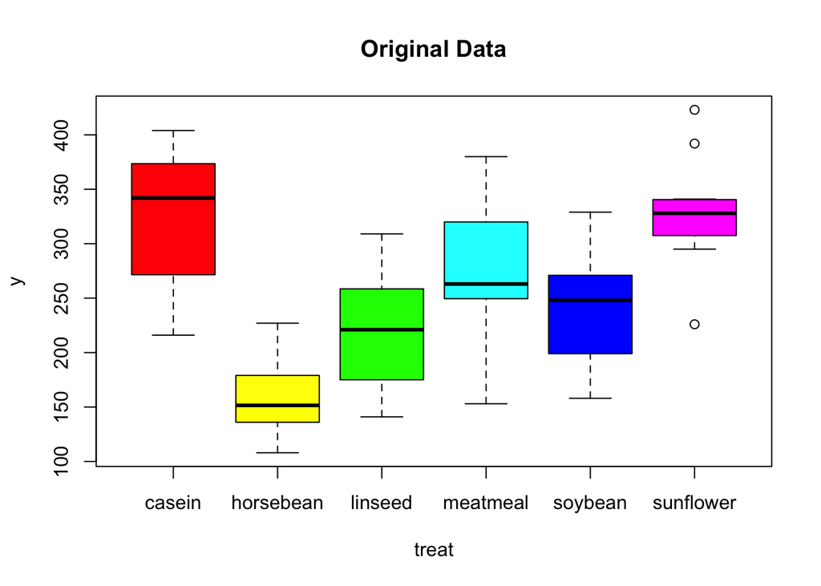

```r
g <- nlevels(feed)
n <- dim(chickwts)[1]


plot(feed, weight, xlab='treat',col=rainbow(g),main='Original Data')
```

The null hypothesis that we want to test is that, being $\tau_i, i\in \{1,\ldots6\}$ the generic effect of a given level of the treatment.
$$H_0: \tau_i=0\;\forall i\;vs\;H_1:\exists\,\tau_i\neq0$$

Of course we can solve this in a fully parametric (and admittedly not robust…) way

```r
fit <- aov(weight ~ feed)
summary(fit)
```

```
##             Df Sum Sq Mean Sq F value   Pr(>F)
## feed         5 231129   46226   15.37 5.94e-10 ***
## Residuals   65 195556    3009
## ---
## Signif. codes:  0 '***' 0.001 '**' 0.01 '*' 0.05 '.' 0.1 ' ' 1
```

The strategy that I use to perform permutational ANOVA is to “permutationalise” the F statistic, by computing her permutational distribution under $H_0$. So…

```r
T0 <- summary(fit)[[1]][1,4]
T0
```

```
## [1] 15.3648
```

To compute the distribution, one simply “scales up” the one used for the 2-sample t-test: I assign at random the treatments (that, under $H_0$, should all be equal, and equal to 0)

```r
T_stat <- numeric(B)
n <- dim(chickwts)[1]

for(perm in 1:B){
  # Permutation:
  permutation <- sample(1:n)
  weight_perm <- weight[permutation]
  fit_perm <- aov(weight_perm ~ feed)

  # Test statistic:
  T_stat[perm] <- summary(fit_perm)[[1]][1,4]
}
```

Let’s see the distribution, and then the p-value of the permutational f-test

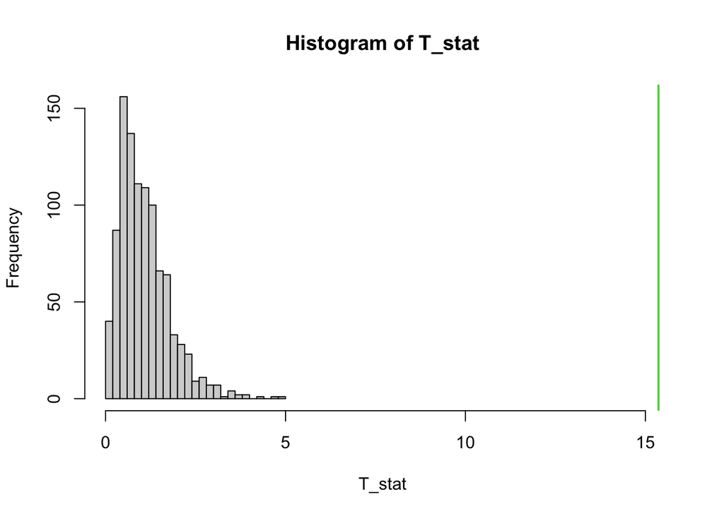

```r
hist(T_stat,xlim=range(c(T_stat,T0)),breaks=30)
abline(v=T0,col=3,lwd=2)
```

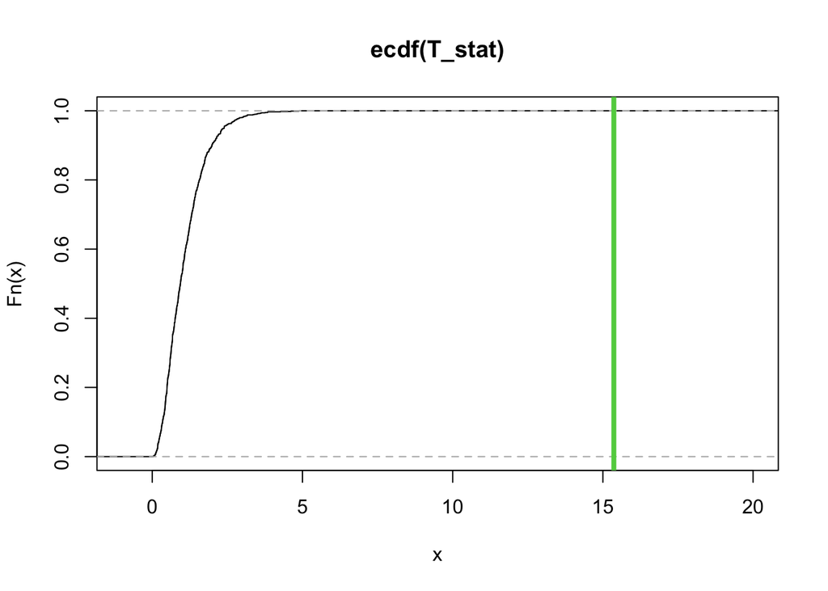

```r
plot(ecdf(T_stat),xlim=c(-1,20))
abline(v=T0,col=3,lwd=4)
```

```r
# p-value
p_val <- sum(T_stat>=T0)/B
p_val
```

```
## [1] 0
```

Let’s see what happens instead when using `lmPerm`

```r
library(lmPerm)
lmp=aovp(weight_perm ~ chickwts$feed,perm="Prob",Cp=0.1)#cp is supposed to stop iterations when standard error is at that level...
```

```
## [1] "Settings:  unique SS "
```

```r
summary(lmp)
```

```
## Component 1 :
##               Df R Sum Sq R Mean Sq Iter Pr(Prob)
## chickwts$feed  5    25825    5165.0  328   0.6372
## Residuals     65   400860    6167.1
```

let’s reduce the expected standard error…

```r
lmp=aovp(weight_perm ~ chickwts$feed,perm="Prob",Cp=1e-6)
```

```
## [1] "Settings:  unique SS "
```

```r
summary(lmp)
```

```
## Component 1 :
##               Df R Sum Sq R Mean Sq Iter Pr(Prob)
## chickwts$feed  5    25825    5165.0  531   0.5348
## Residuals     65   400860    6167.1
```

and let’s run the instruction several times

```r
lmp=aovp(weight_perm ~ chickwts$feed,perm="Prob",Cp=1e-6)
```

```
## [1] "Settings:  unique SS "
```

```r
summary(lmp)
```

```
## Component 1 :
##               Df R Sum Sq R Mean Sq Iter Pr(Prob)
## chickwts$feed  5    25825    5165.0  229   0.4629
## Residuals     65   400860    6167.1
```

```r
lmp=aovp(weight_perm ~ chickwts$feed,perm="Prob",Cp=1e-6)
```

```
## [1] "Settings:  unique SS "
```

```r
summary(lmp)
```

```
## Component 1 :
##               Df R Sum Sq R Mean Sq Iter Pr(Prob)
## chickwts$feed  5    25825    5165.0  659   0.5933
## Residuals     65   400860    6167.1
```

```r
lmp=aovp(weight_perm ~ chickwts$feed,perm="Prob",Cp=1e-6)
```

```
## [1] "Settings:  unique SS "
```

```r
summary(lmp)
```

```
## Component 1 :
##               Df R Sum Sq R Mean Sq Iter Pr(Prob)
## chickwts$feed  5    25825    5165.0  311   0.5177
## Residuals     65   400860    6167.1
```

**Doesn’t really make much sense. Don’t use it.**

## Multivariate Analysis of Variance

The strategy behind the multivariate analysis of variance is admittedly fairly similar. We use the Iris dataset

```r
data(iris)
attach(iris)
head(iris)
```

|  | Sepal.Length | Sepal.Width | Petal.Length | Petal.Width | Species |
| --- | --- | --- | --- | --- | --- |
| 1 | 5.1 | 3.5 | 1.4 | 0.2 | setosa |
| 2 | 4.9 | 3.0 | 1.4 | 0.2 | setosa |
| 3 | 4.7 | 3.2 | 1.3 | 0.2 | setosa |
| 4 | 4.6 | 3.1 | 1.5 | 0.2 | setosa |
| 5 | 5.0 | 3.6 | 1.4 | 0.2 | setosa |
| 6 | 5.4 | 3.9 | 1.7 | 0.4 | setosa |

```r
table(iris$Species)
```

```
##
##     setosa versicolor  virginica
##         50         50         50
```

let’s arrange it a bit, and plot it.

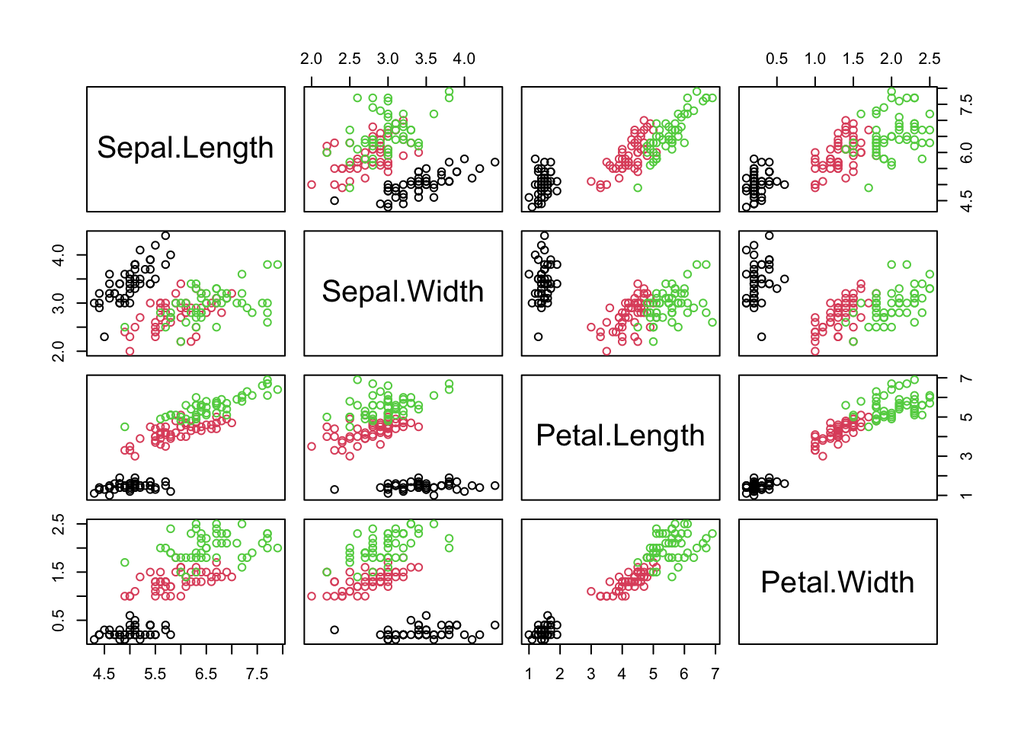

```r
species.name <- factor(Species, labels=c('setosa','versicolor','virginica'))
iris4        <- iris[,1:4]
plot(iris4,col=species.name)
```

```r
i1 <- which(species.name=='setosa')
i2 <- which(species.name=='versicolor')
i3 <- which(species.name=='virginica')
n1 <- length(i1)
n2 <- length(i2)
n3 <- length(i3)
n  <- n1+n2+n3

g  <- length(levels(species.name))
p  <- 4
```

How to perform a MANOVA test? instead of using the F-test, we will develop a test based on a “permutationalisation” of the Wilks test. Let’s compute the permutational test statistic

```r
fit <- manova(as.matrix(iris4) ~ species.name)
summary.manova(fit,test="Wilks")
```

```
##               Df    Wilks approx F num Df den Df    Pr(>F)
## species.name   2 0.023439   199.15      8    288 < 2.2e-16 ***
## Residuals    147
## ---
## Signif. codes:  0 '***' 0.001 '**' 0.01 '*' 0.05 '.' 0.1 ' ' 1
```

```r
T0 <- -summary.manova(fit,test="Wilks")$stats[1,2]
T0
```

```
## [1] -0.02343863
```

And let’s now compute instead the permutational distribution of the test statistic.

```r
set.seed(seed)
T_stat <- numeric(B)

for(perm in 1:B){
  # choose random permutation
  permutation <- sample(1:n)
  species.name.perm <- species.name[permutation]
  fit.perm <- manova(as.matrix(iris4) ~ species.name.perm)
  T_stat[perm] <- -summary.manova(fit.perm,test="Wilks")$stats[1,2]
}
```

Let’s visualize again the distribution, and the p-value

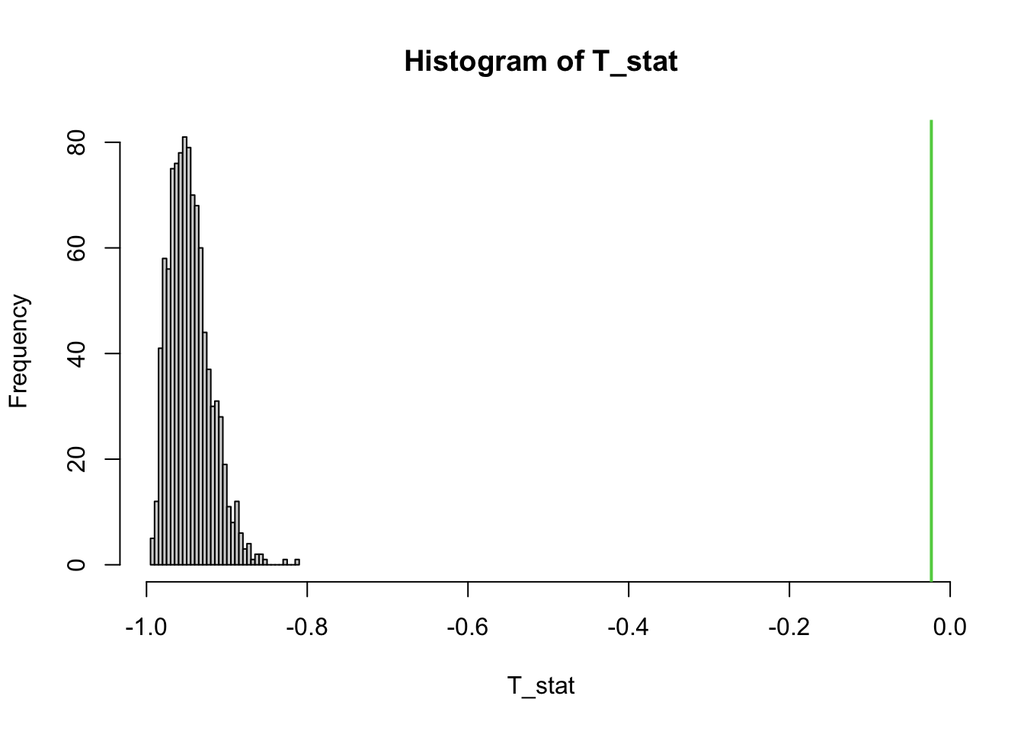

```r
hist(T_stat,xlim=range(c(T_stat,T0)),breaks=30)
abline(v=T0,col=3,lwd=2)
```

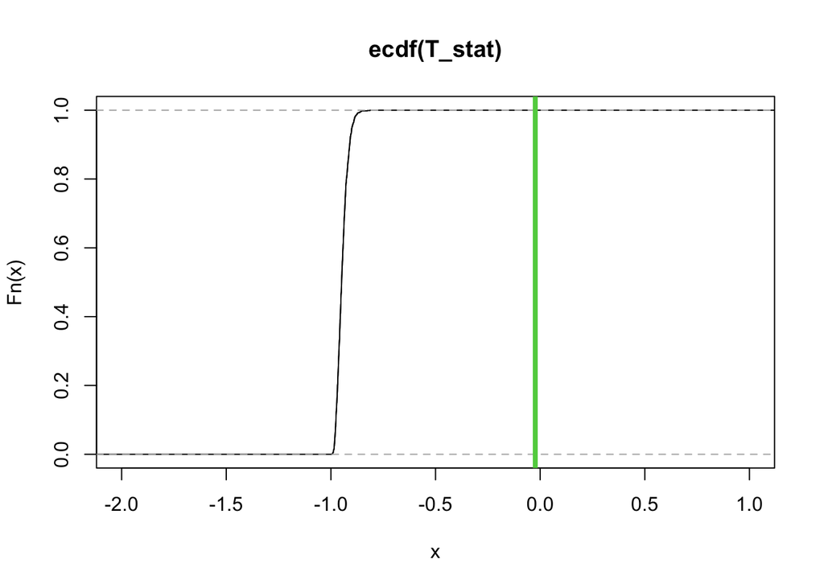

```r
plot(ecdf(T_stat),xlim=c(-2,1))
abline(v=T0,col=3,lwd=4)
```

```r
# p-value
p_val <- sum(T_stat>=T0)/B
p_val
```

```
## [1] 0
```

Up to now, everything is fairly easy. The situation gets a bit uglier when more than one factor is involved in the model

## Permutational Two-Way ANOVA

In this case we wan to test the efficiency of a car with different fuels, which are classified by their **producer** or by their **octane** number. I want to see what are the meaningful factors in determining the number of kilometers performed with a liter of petrol, interaction included…

This time the data is put in by hand…

```r
km          <- c(18.7, 16.8, 20.1, 22.4, 14.0, 15.2, 22.0, 23.3)
station     <- factor(c('Esso','Esso','Esso','Esso','Shell','Shell','Shell','Shell'))
fuel        <- factor(c('95','95','98','98','95','95','98','98'))
station_fuel<- factor(c('Esso95','Esso95','Esso98','Esso98','Shell95','Shell95','Shell98','Shell98'))

M             <- mean(km)
Mstation      <- tapply(km,      station, mean)
Mfuel         <- tapply(km,       fuel, mean)
Mstation_fuel <- tapply(km, station_fuel, mean)
```

Let’s also plot the data

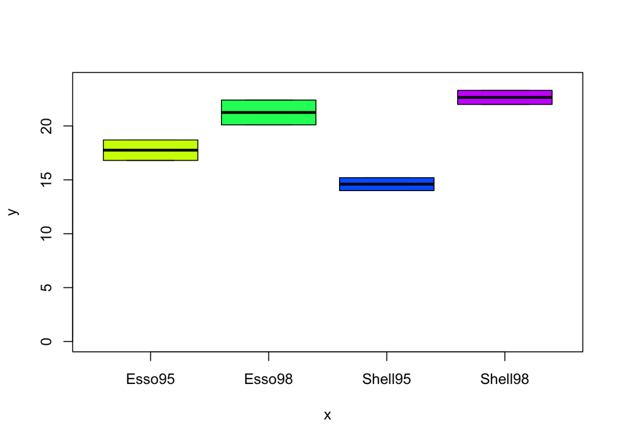

```r
plot(station_fuel, km, col=rainbow(5)[2:5], ylim=c(0,24))
```

and, of course, I can do everything in a fully parametric setting…

```r
# Parametric test:
summary(aov(km ~ station + fuel + station:fuel))
```

```
##              Df Sum Sq Mean Sq F value  Pr(>F)
## station       1   1.53    1.53   1.018 0.37001
## fuel          1  66.70   66.70  44.357 0.00264 **
## station:fuel  1  10.35   10.35   6.884 0.05857 .
## Residuals     4   6.01    1.50
## ---
## Signif. codes:  0 '***' 0.001 '**' 0.01 '*' 0.05 '.' 0.1 ' ' 1
```

```r
# Without interaction
summary.aov(aov(km ~ station + fuel))
```

```
##             Df Sum Sq Mean Sq F value  Pr(>F)
## station      1   1.53    1.53   0.468 0.52440
## fuel         1  66.70   66.70  20.378 0.00632 **
## Residuals    5  16.37    3.27
## ---
## Signif. codes:  0 '***' 0.001 '**' 0.01 '*' 0.05 '.' 0.1 ' ' 1
```

```r
# Without station
summary.aov(aov(km ~ fuel))
```

```
##             Df Sum Sq Mean Sq F value  Pr(>F)
## fuel         1   66.7   66.70   22.36 0.00323 **
## Residuals    6   17.9    2.98
## ---
## Signif. codes:  0 '***' 0.001 '**' 0.01 '*' 0.05 '.' 0.1 ' ' 1
```

**To do everything in a permutational setting, I need to recognize that, actually, the tests that I need to run are more than one!**

The two-way ANOVA model that I want to write is:
$$Km = \mu + \alpha_i + \beta_j + \gamma_{ij} + \epsilon$$

So, I need to see if $\gamma=0$, or $\beta=0$ or $\alpha=0$ and, for each of this tests, I have a different permutation scheme.

Let’s start with the $H_0:\gamma=0$ vs $H_1:\gamma\neq0$. Under the null hypothesis the model reduces to the additive one: $Km = \mu + \alpha_i + \beta_j + \epsilon$, and **permuting the residuals** under this model should yield likelihood-invariant datasets. So, let’s compute the test statistic

```r
summary.aov(aov(km ~ station + fuel + station:fuel))
```

```
##              Df Sum Sq Mean Sq F value  Pr(>F)
## station       1   1.53    1.53   1.018 0.37001
## fuel          1  66.70   66.70  44.357 0.00264 **
## station:fuel  1  10.35   10.35   6.884 0.05857 .
## Residuals     4   6.01    1.50
## ---
## Signif. codes:  0 '***' 0.001 '**' 0.01 '*' 0.05 '.' 0.1 ' ' 1
```

```r
T0_station_fuel <- summary.aov(aov(km ~ station + fuel + station:fuel))[[1]][3,4]
T0_station_fuel
```

```
## [1] 6.883624
```

and instead compute the permutational distribution:

```r
aov.H0station_fuel <- aov(km ~ station + fuel)
aov.H0station_fuel
```

```
## Call:
##    aov(formula = km ~ station + fuel)
##
## Terms:
##                  station     fuel Residuals
## Sum of Squares   1.53125 66.70125  16.36625
## Deg. of Freedom        1        1         5
##
## Residual standard error: 1.809213
## Estimated effects may be unbalanced
```

```r
residuals.H0station_fuel <- aov.H0station_fuel$residuals
n = 8


T_station_fuel <- numeric(B)
for(perm in 1:B){
  permutation <- sample(n)
  residuals.H0station_fuel <- residuals.H0station_fuel[permutation]
  km.perm.H0station_fuel <- aov.H0station_fuel$fitted + residuals.H0station_fuel
  T_station_fuel[perm] <- summary.aov(aov(km.perm.H0station_fuel ~ station + fuel + station:fuel))[[1]][3,4]
}
```

And the p-value…

```r
sum(T_station_fuel >= T0_station_fuel)/B
```

```
## [1] 0.073
```

Not significant, meaning that I can reduce the model and then perform my test on my main effects. To test $H_0:\beta=0$ vs $H_1:\beta\neq 0$, I am assuming under $H_0$ the following model $Km = \mu + \alpha_i + \epsilon$, while for $H_0:\alpha=0$ vs $H_1:\alpha\neq0$ I am assuming $Km = \mu + \beta_j + \epsilon$

Again, the idea is to permute the residuals under $H_0$, so let’s compute them

```r
# Test for station
T0_station <- summary.aov(aov(km ~ station + fuel))[[1]][1,4]
# residuals under H0:
# km = mu + beta*fuel
aov.H0station <- aov(km ~ fuel)
residuals.H0station <- aov.H0station$residuals

# Test for fuel
T0_fuel <- summary.aov(aov(km ~ station + fuel))[[1]][2,4]
# residuals under H0:
# km = mu + alpha*station
aov.H0fuel <- aov(km ~ station)
residuals.H0fuel <- aov.H0fuel$residuals
```

And let’s now compute the permutational distribution, and thus the p-value

```r
# Test both factors in a single loop
B <- 1000
T_fuel <- T_station <- numeric(B)
for(perm in 1:B){
  permutation <- sample(n)

  # Test station
  km.perm.H0station <- aov.H0station$fitted + residuals.H0station[permutation]
  T_station[perm] <- summary.aov(aov(km.perm.H0station ~ station + fuel))[[1]][1,4]

  # Test fuel
  km.perm.H0fuel <- aov.H0fuel$fitted + residuals.H0fuel[permutation]
  T_fuel[perm] <- summary.aov(aov(km.perm.H0fuel ~ station + fuel))[[1]][2,4]
}
```

```r
sum(T_station >= T0_station)/B
```

```
## [1] 0.541
```

```r
sum(T_fuel >= T0_fuel)/B
```

```
## [1] 0.032
```

In histograms

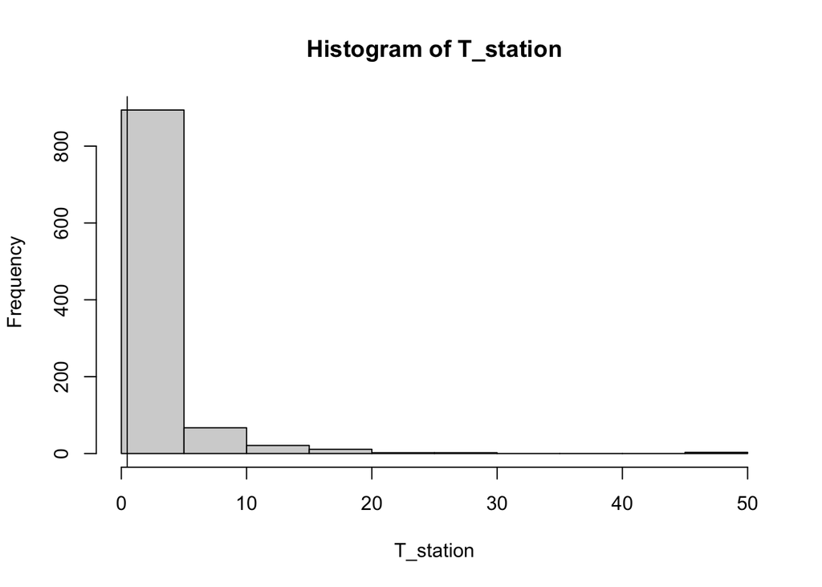

```r
hist(T_station)
abline(v=T0_station)
```

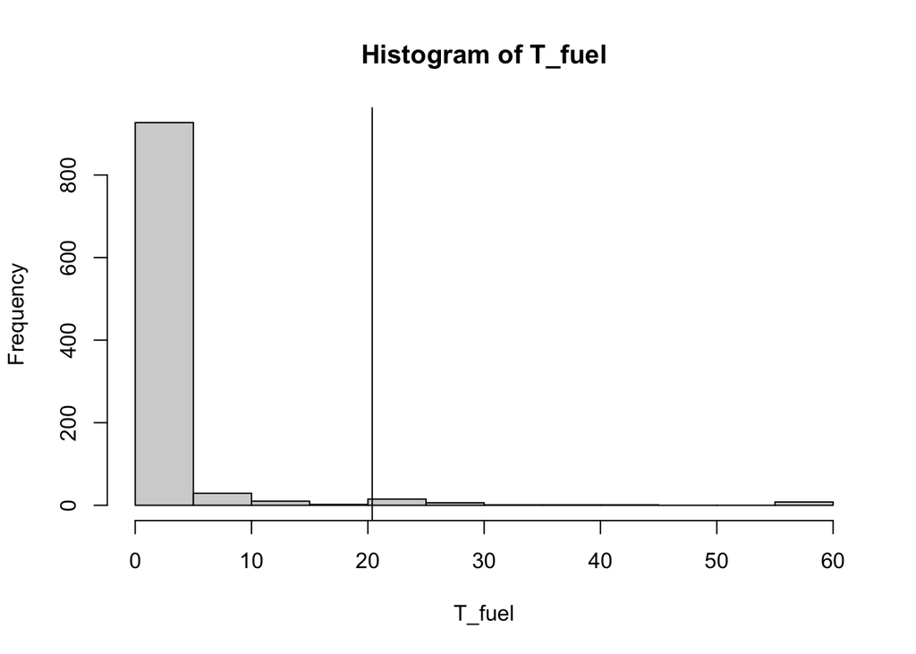

```r
hist(T_fuel)
abline(v=T0_fuel)
```

I can remove station, so let’s go on on testing Fuel… which actually is a one-way ANOVA… **It can be shown in this case the residual permutation and the data permutation are the same**…

```r
# TEST ON THE FACTOR FUEL
T0_fuel <- summary.aov(aov(km ~  fuel))[[1]][1,4]
# residuals under H0
# km = mu
residuals.H0fuel <- km - M

# Note that in this case, permuting the residuals under H0
# and permuting the data is exactly the same:
permutation <- sample(n)
km.perm.H0fuel <- M + residuals.H0fuel[permutation]
km.perm        <- km[permutation]

km.perm.H0fuel
```

```
## [1] 20.1 14.0 16.8 15.2 23.3 22.0 18.7 22.4
```

```r
km.perm
```

```
## [1] 20.1 14.0 16.8 15.2 23.3 22.0 18.7 22.4
```

```r
T_fuel <- numeric(B)
for(perm in 1:B){
  permutation <- sample(n)
  km.perm <- km[permutation]
  T_fuel[perm] <- summary.lm(aov(km.perm ~ fuel ))$f[1]

}
sum(T_fuel >= T0_fuel)/B
```

```
## [1] 0
```